# Spatial Join Tutorial

Marynia Kolak

November 2017

```r
require(spatialEco)
library(rgdal)
library(foreign)
```

The code below demonstrates spatial join and aggregation examples using [spatialeco](https://cran.r-project.org/web/packages/spatialEco/index.html), foreign, and [rgdal](https://cran.r-project.org/web/packages/rgdal/rgdal.pdf) packages. Some code snippets from the Spatial Data Science introduction course (authored by Luc Anselin) were used from the [Center for Spatial Data Science](https://spatial.uchicaog.edu).

## Data Preparation

You must have two spatial data files to start. Lat and long column fields do not make the data spatial; it must be converted to a spatial format such as .shp (shapefile), geojson, and so forth. These formats should include the appropriate project.

Data used in this tutorial, [produce carts](https://data.cityofchicago.org/Community-Economic-Development/Produce-Carts/divg-mhqk) and [Community Area boundaries](https://data.cityofchicago.org/Facilities-Geographic-Boundaries/Boundaries-Community-Areas-current-/cauq-8yn6), were downloaded from the City of Chicago Data Portal. The community area data was exported as a shapefile. The produce cart dataset was uploaded to GeoDa, and converted to spatial format using the provided latitute and longitude.

## Load Spatial Data

Import two spatial files with your data. Here, I first import my points shapefile representing produce carts in Chicago. Then second file is the area of interest that I’m aggregating my stations to; Community Areas of Chicago.

Your data must have the following extensions as a shapefile: .shp, .shx, .dbf, and .prj. The .prj file includes the projection of the data. For a spatial join, both datasets must be in the same projection!

### Point Data - Produce Carts in Chicago

Read shapefile

```r
pts<- readOGR(".","Produce_Carts")
```

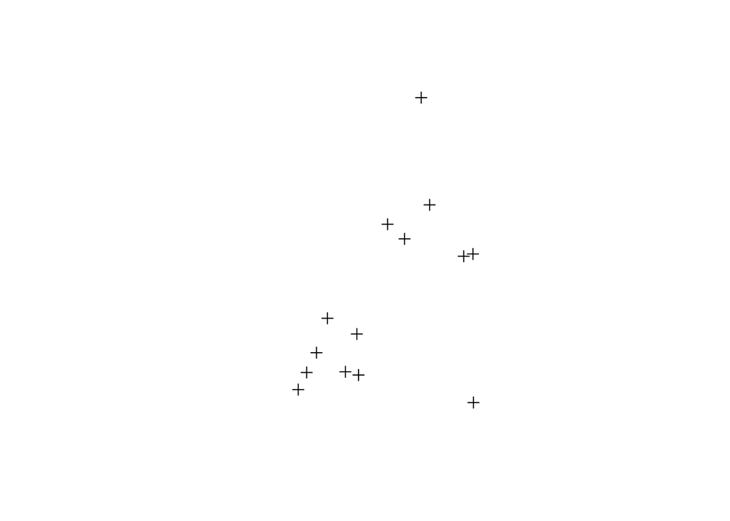

```r
# Plot points for inspection
plot(pts)
```

```r
# Check length of data
length(pts)
```

```
## [1] 14
```

```r
# Inspect data. Note here that the produce cart location field is incorrent (should be long,lat), though we have the corrected version implemented in our spatial metadata.
head(pts@data)
```

```
##              ADDRESS LATITUDE LONGITUDE                    LOCATION
## 1  721 N LA SALLE DR 41.89558 -87.63254 (41.89557507, -87.63254328)
## 2   4602 N BROADWAY  41.96548 -87.65769 (41.96547764, -87.65768753)
## 3   25 E CHICAGO AVE 41.89658 -87.62709 (41.89658176, -87.62708766)
## 4   3758 W OGDEN AVE 41.85308 -87.71965 (41.85307985, -87.71965154)
## 5     4020 W 26TH ST 41.84435 -87.72546 (41.84435111, -87.72545519)
## 6 1601 W DIVISION ST 41.90324 -87.66755 (41.90323582, -87.66755407)
```

### Polygon Data - Community Areas (ie. Neighorhoods) in Chicago

```r
# Read shapefile
polys<-readOGR(".","ComArea")
```

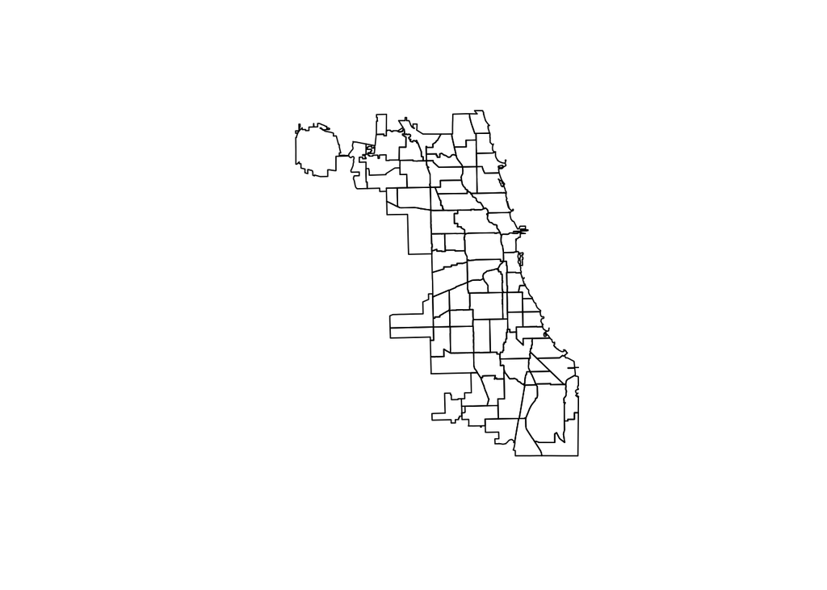

```r
# Plot polygons for inspection
plot(polys)
```

```r
# Inspect data.
head(polys@data)
```

```
##   ComAreaID       community
## 0        35         DOUGLAS
## 1        36         OAKLAND
## 2        37     FULLER PARK
## 3        38 GRAND BOULEVARD
## 4        39         KENWOOD
## 5         4  LINCOLN SQUARE
```

## Spatial Join

Use spatialEco function: point.in.poly. This funciton intersects point and polygon feature classes and adds polygon attributes to points.

```r
pts.poly <- point.in.poly(pts, polys)
```

## Aggregate points per polygon

There are many ways to do this. In this example, I use the table function in R to create a frequency of produce carts (points) per community area (polygons).

```r
carts_total<- table(pts.poly$ComAreaID)
cartsframe<- as.data.frame(carts_total)
head(cartsframe)
```

```
##   Var1 Freq
## 1    3    1
## 2    7    1
## 3    8    2
## 4   24    2
## 5   29    3
## 6   30    4
```

```r
dim(cartsframe)
```

```
## [1] 7 2
```

## Data Cleaning

Because there are only a few community areas represented by produce carts, we need to join frequencies to a new, empty vector that matches the Community Area length.

```r
#Check if Var1 is a factor; if it is, we need to change.
is.factor(cartsframe$Var1)
```

```
## [1] TRUE
```

```r
#We convert Var 1 from factor to level to numeric.
nnf<- cartsframe$Var1
levels(nnf)
```

```
## [1] "3"  "7"  "8"  "24" "29" "30" "35"
```

```r
nnn<- as.numeric(levels(nnf))
nnn
```

```
## [1]  3  7  8 24 29 30 35
```

```r
is.factor(nnn)
```

```
## [1] FALSE
```

```r
# Create a new, empty vector that is the length of Community Area polygons
narea<- max(comarea$ComAreaID)
vc<- vector(mode="numeric",length=narea)
vc
```

```
##  [1] 0 0 0 0 0 0 0 0 0 0 0 0 0 0 0 0 0 0 0 0 0 0 0 0 0 0 0 0 0 0 0 0 0 0 0
## [36] 0 0 0 0 0 0 0 0 0 0 0 0 0 0 0 0 0 0 0 0 0 0 0 0 0 0 0 0 0 0 0 0 0 0 0
## [71] 0 0 0 0 0 0 0
```

```r
length(vc)
```

```
## [1] 77
```

```r
vc[nnn]<- egoframe$Freq
vc
```

```
##  [1] 0 0 1 0 0 0 1 2 0 0 0 0 0 0 0 0 0 0 0 0 0 0 0 2 0 0 0 0 3 4 0 0 0 0 1
## [36] 0 0 0 0 0 0 0 0 0 0 0 0 0 0 0 0 0 0 0 0 0 0 0 0 0 0 0 0 0 0 0 0 0 0 0
## [71] 0 0 0 0 0 0 0
```

## Write data

Once we have the data set up how we’d like it, we convert to a data frame, update column names, and write to a csv. That csv can later be joined to the community area shapefile we have (using R, Geoda, or another option).

```r
# Finalize new data frame
nid <- (1:narea)
vcframe <- data.frame(as.integer(nid),as.integer(vc))
names(vcframe)<- c("CID","producecarts")

# Write data as csv for joining in Geoda.
write.csv(vcframe,"produce-carts-by-CA.csv",row.names=FALSE)
```